# Capstone Project-1

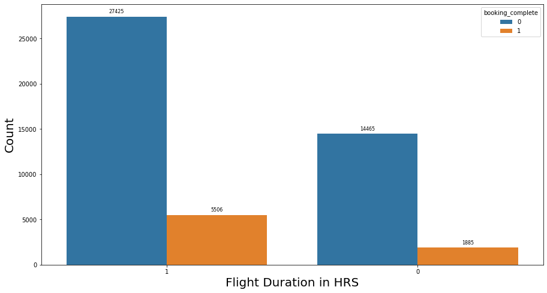

```python
# trip type and booking complete
plt.figure(figsize=(15,8))
plots = sns.countplot(x="wants_extra_baggage", hue="booking_complete" , data=data ,order=data.wants_extra_baggage.value_counts().index)#.iloc[-10:].index)
plt.xlabel("Flight Duration in HRS",fontsize= 20)
plt.ylabel("Count", fontsize= 20)

for bar in plots.patches:
    plots.annotate(format(bar.get_height()),(bar.get_x() + bar.get_width() / 2,bar.get_height()),
                   ha='center', va='center',size=8, xytext=(0, 8),textcoords='offset points')
```

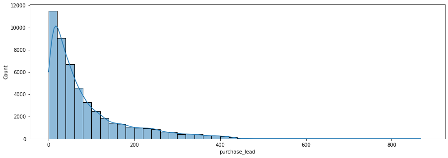

```python
# Purchase Lead
plt.figure(figsize=(15,5))
sns.histplot(data, x="purchase_lead", binwidth=20,kde=True)
```

### There are few bookings that were done more than 2 years before the travel date and it seems very unlikely that book that in advance. However, it might also be because of the cancellation and rebooking in a period of 6 months for twice. But at this point we will consider them as outliers which will effect the results of predictive model in a huge way.

# Length Of Stay

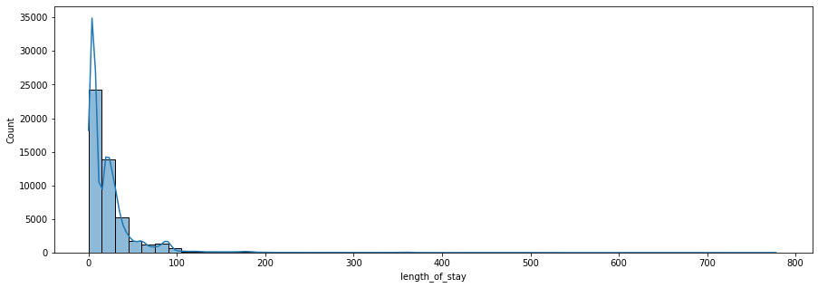

```python
plt.figure(figsize=(15,5))
sns.histplot(data, x="length_of_stay", binwidth=15,kde=True)
plt.show()
```

# Booking complete

```python
data["booking_complete"].value_counts()
```

```
0    41890
1     7391
Name: booking_complete, dtype: int64
```

```python
values = [41890,7391]
labels=["Not completed","Completed"]
fig = px.pie(values=values,names=labels)
fig.show()
```

[interactive chart not shown]

# travellers from which country had their booking complete.

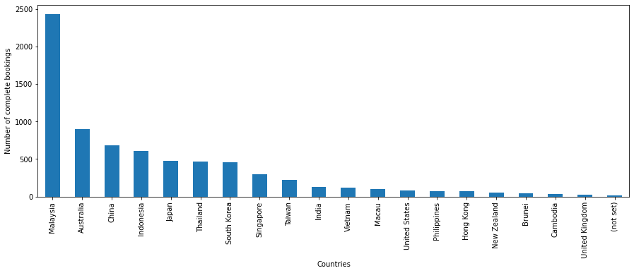

```python
plt.figure(figsize=(15,5))
ax = data[data.booking_complete ==1].booking_origin.value_counts()[:20].plot(kind="bar")
ax.set_xlabel("Countries")
ax.set_ylabel("Number of complete bookings")
```